# Clustering

JMitchell

June 20, 2016

## Introduction:

This is a quick introduction to Heirarchical Clustering, K-Means Clustering, and PCA and SVD analysis that I put together primarily for my own reference. This page does not go into the theory or details of any calculations. It’s more just to give an intuitive explanation of the concepts and show some of the functionality and display properties of a few R functions. The code on this page is based heavily on the lectures from Coursera’s Johns Hopkins [Exploratory Data Analysis](https://www.coursera.org/specializations/jhu-data-science) Class with lectures by Professor Robert D. Peng. Great Course, Thank you Dr. Peng!

## Heirarchical Clustering:

- Lets generate some data to start:

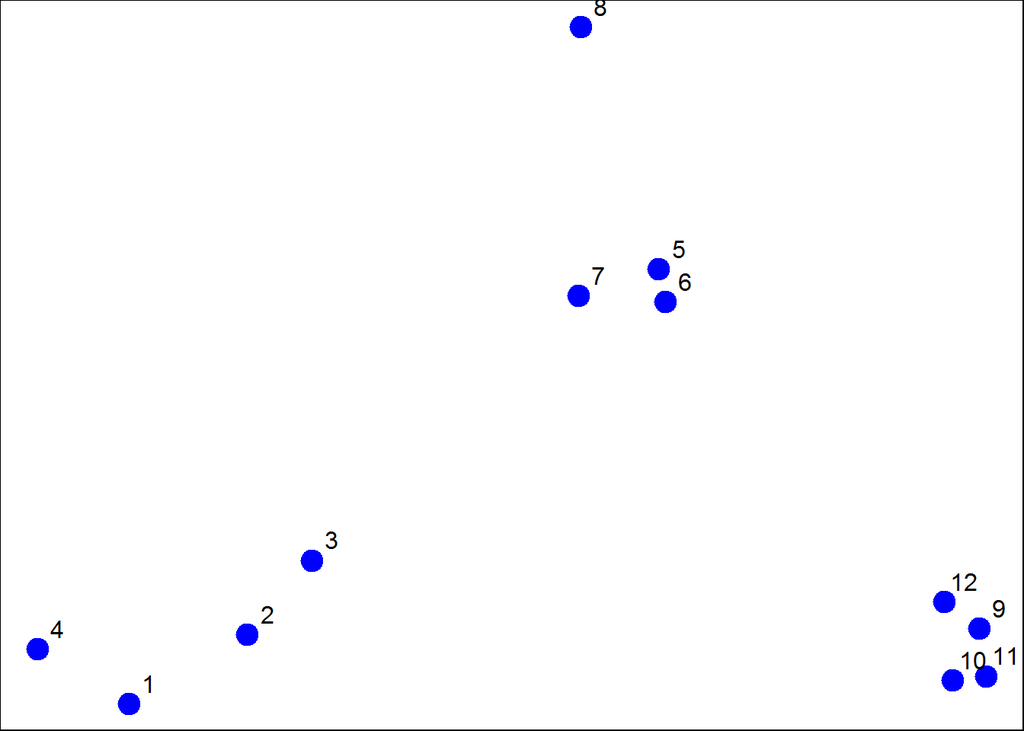

```r
set.seed(1234)
par(mar=c(0,0,0,0))
x<- rnorm(12, mean=rep(1:3, each=4), sd=0.2)
y <- rnorm(12, mean=rep(c(1,2,1), each=4), sd=.2)

plot(x,y, col="blue", pch=19, cex=2)
text(x+ 0.05, y+0.05, labels=as.character(1:12))
```

### Observation:

There are three pretty obvious groups of data on this plot, as one would expect based on the parameters passed to rnorm above. The different specifications for the mean arg for x and y generate the clusters around 1,2,3 on the x axis, and 1,2,1 on the y-axis. So let’s Look at a few differnet ways of clustering and analyizing this example dataset:

### hclust()

- Next, load the data into a dataFrame, and break it up intp trees:

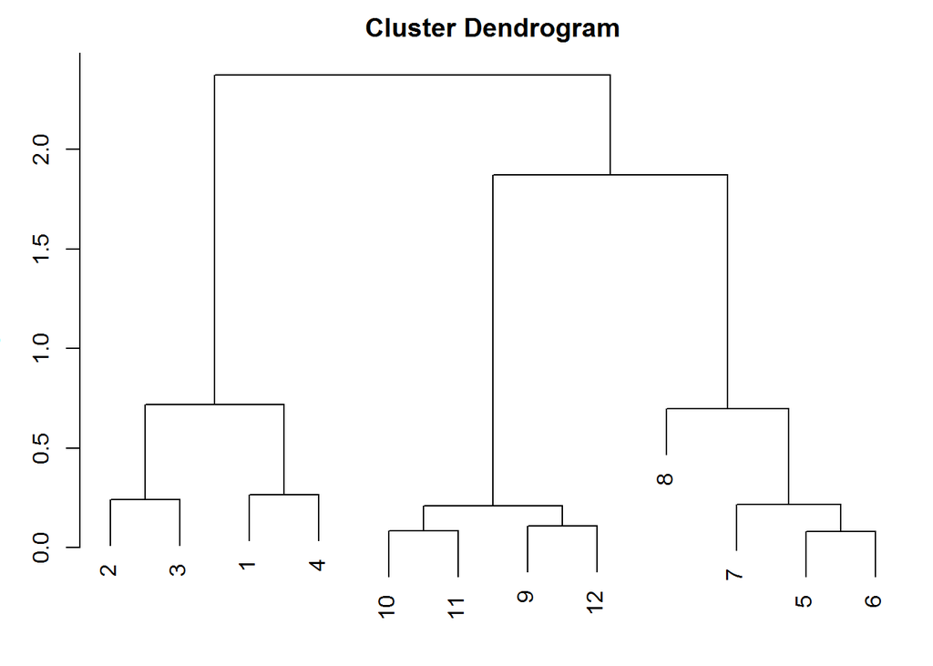

```r
df <- data.frame(x=x,y=y)
distxy <- dist(df)

hClustering <- hclust(distxy)

par(mar=c(1,3,2,1))
plot(hClustering)
```

### Observation:

- Note that the Dendrogram does not specify how many clusters there are. It shows all possible clustering levels, so the zero value on the y axis would give you the trivial answer where every datapoint is it’s own cluster, whereas higher up on the grap at y=2 the dataset has been lumped into two groups. While this dataset has 3 pretty obvious clusters, in real data it is not always intuituve where the correct level of clustering falls. A geologist would refer to this as an example of “Lumping vs Splitting.”
- **Merging Methods:** This refers to the moethod used to calculate the distance betwen points/clusters. Two common methods are *Complete* and *Average* to determine size/location of newly merged points/clusters. This can have a large effect on the outcome of the clster analysis.

### heatmap()

- Let’s take a look at the same data in a heatmap.

```r
# change df into a matrix and randomize the rows
# we're randomizint them just to show that heatmap() will
# resort them according to cluster
set.seed(143)
dm <- as.matrix(df)[sample(1:12),]
dm
```

```
##               x         y
##  [1,] 2.8003227 1.0919179
##  [2,] 0.7585869 0.8447492
##  [3,] 1.8906736 2.4831670
##  [4,] 0.5308605 0.9779429
##  [5,] 2.9045615 0.9118904
##  [6,] 1.8850520 1.8325657
##  [7,] 2.8871096 1.0268176
##  [8,] 1.2168882 1.1918988
##  [9,] 2.0858249 1.8977981
## [10,] 1.0554858 1.0128918
## [11,] 2.8219924 0.9018628
## [12,] 2.1012112 1.8177609
```

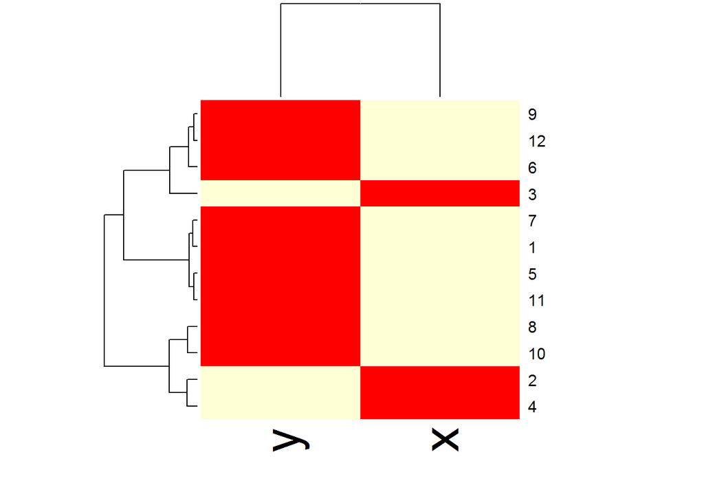

```r
heatmap(dm)
```

### A few Notes:

- The Pictue may be unstable, due to
- outliers
- data changes
- distance and merging methods used
- the scale (units) of the variables. May need to rescale some variables.

## K-Means Clustering.

- Must determine distance mesuarment method:
  - Euclidean,
  - Correlation
  - Manhattan.
- Easy to make Garbage In <- Garbage Out!
- Inputs:
  - Distance Method
  - number of clusters *initial guess to cluster centroids

### kmeans()

```r
kmeansObj <- kmeans(df, centers=3)
names(kmeansObj)
```

```
## [1] "cluster"      "centers"      "totss"        "withinss"
## [5] "tot.withinss" "betweenss"    "size"         "iter"
## [9] "ifault"
```

```r
kmeansObj$cluster
```

```
##  [1] 2 2 2 2 1 1 1 1 3 3 3 3
```

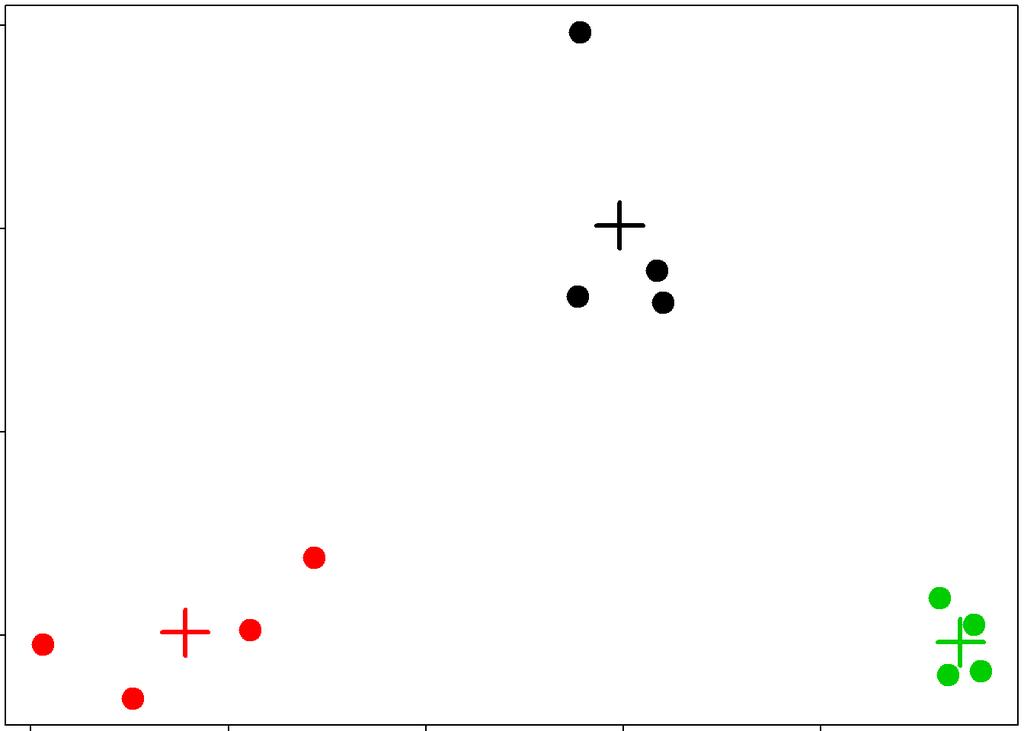

```r
par(mar=rep(0.2,4))
plot(x,y,col = kmeansObj$cluster, pch=19, cex=2)
points(kmeansObj$centers,col=1:3, pch=3, cex=3, lwd=3)
```

### Heatmaps:

- Looking at the same data as above, compare the original randomized data in dm (left) with the k-means clustered data (right) This particular plot is not that interesting, but with a larger matix it’s a good visualiztion tool of higher dim data.

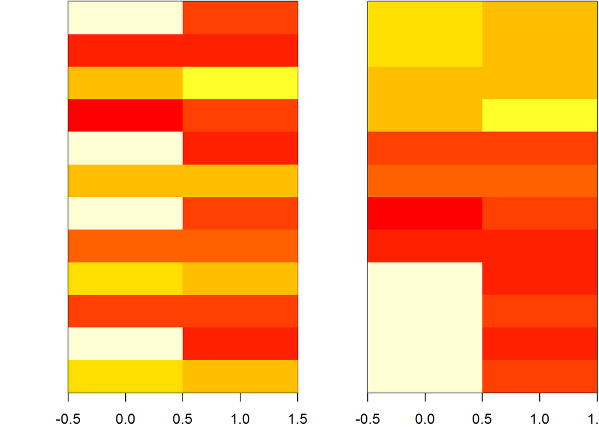

```r
#lets re-use the matrix dm from above:
kmeansObj2 <- kmeans(dm, centers=3)
par(mfrow=c(1,2), mar= c(2,4,.1,.1))

image(t(dm)[ , nrow(dm):1], yaxt="n")
image(t(dm)[ , order(kmeansObj2$cluster)], yaxt="n")
```

## Pricnipal Component Analysis (PCA)

Lets start with a bigger dataset for this part:

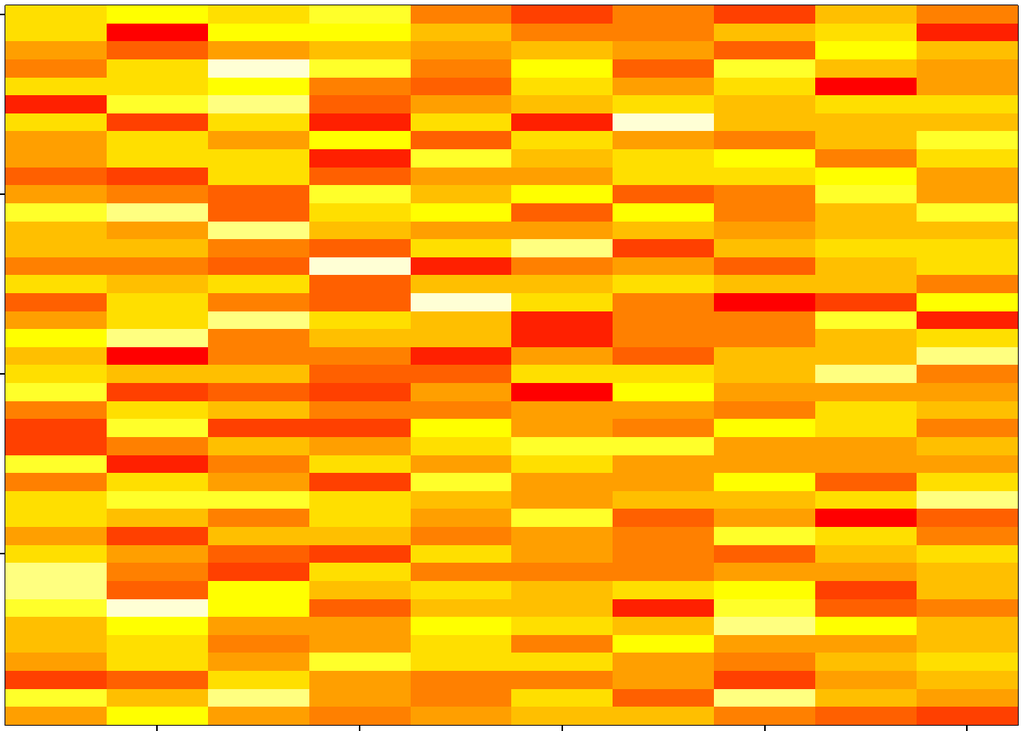

```r
set.seed(12345)
par(mar=rep(0.2,4))
dm <- matrix(rnorm(400), nrow=40)
image(1:10,1:40, t(dm)[, nrow(dm):1])
```

- Not much parttern to see…
- Let’s cluster the data and look at a heatmap:

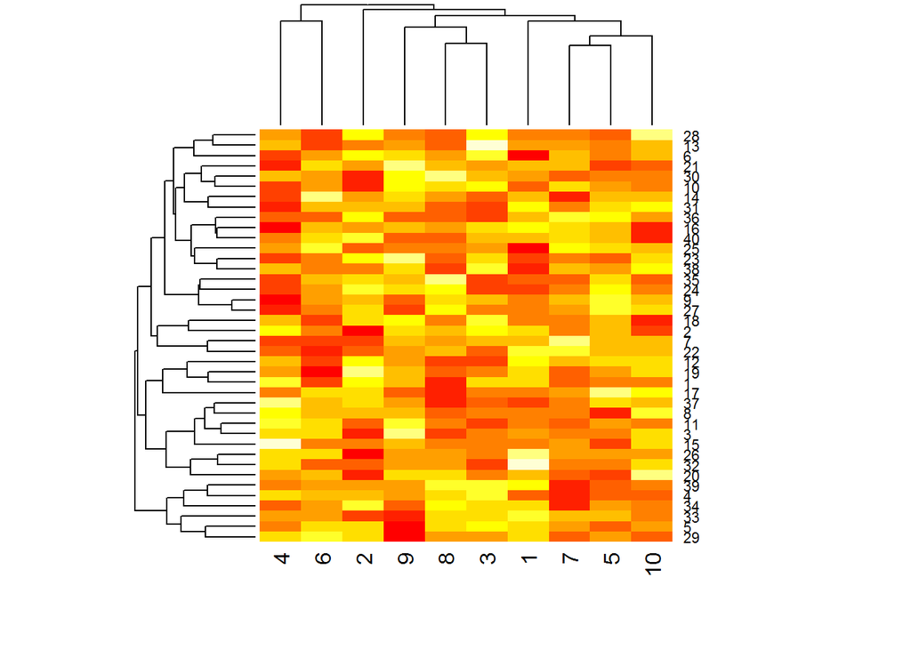

```r
heatmap(dm)
```

- Let’s add a pattern to the data:

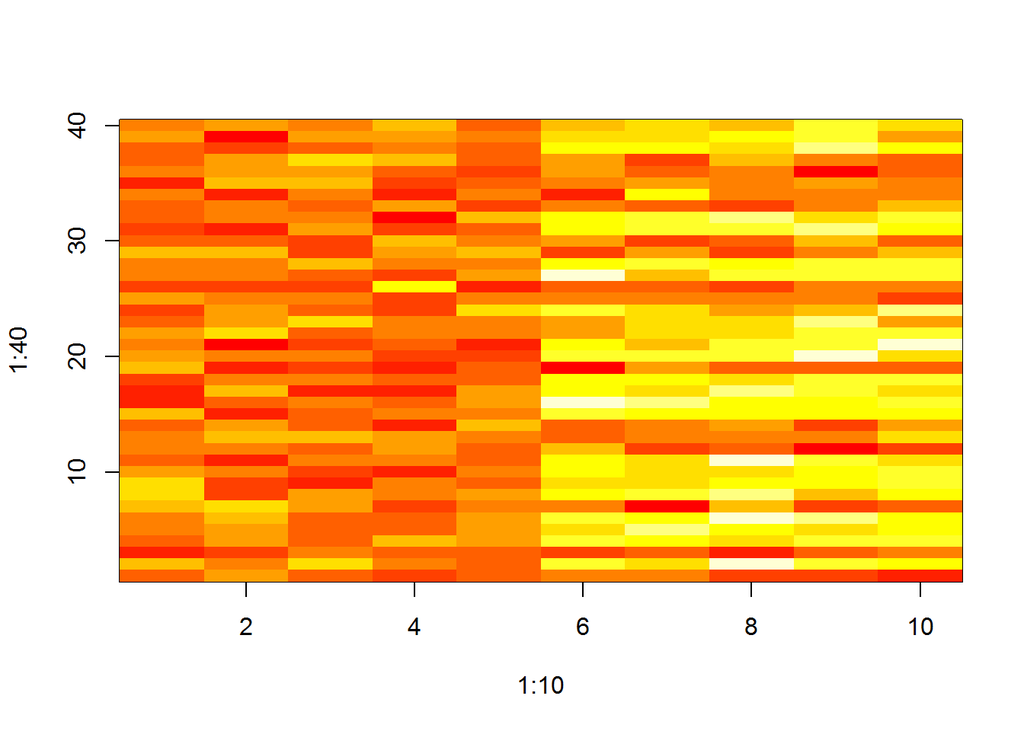

```r
set.seed(678910)
for (i in 1:40) {
        #flip a coin
        coinFlip <- rbinom(1, size=1, prob=0.5)
        #if heads add a common pattern to that row
        if (coinFlip) {
                dm[i, ] <- dm[i,] + rep(c(0,3), each=5)
        }
}

image(1:10,1:40, t(dm)[, nrow(dm):1])
```

- And Now take a look at the Heatmap:

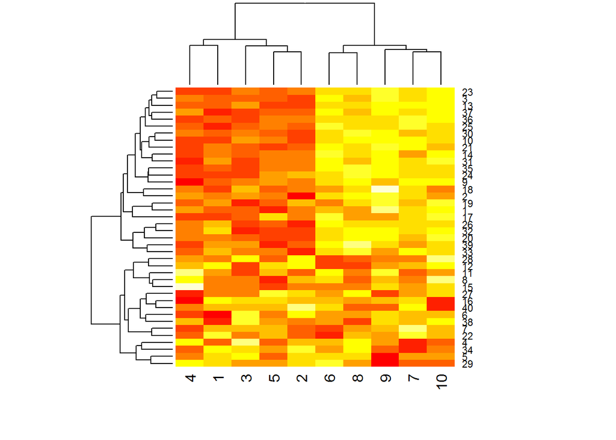

```r
heatmap(dm)
```

- Row and Column Patterns:

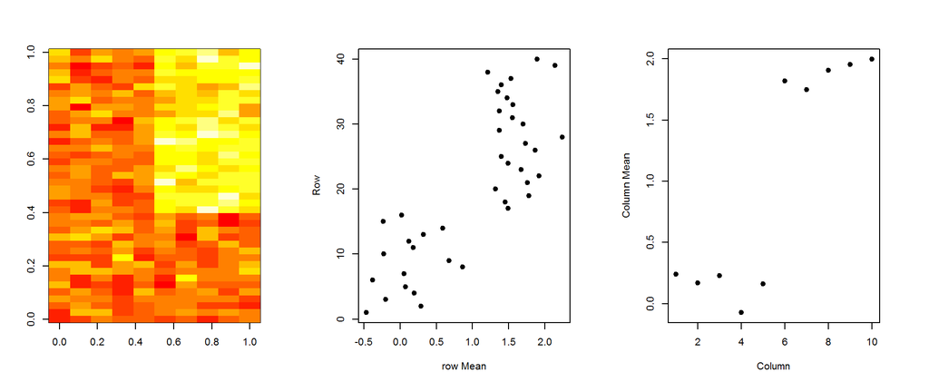

```r
#  Lets look at patterns in the Rows and colums:

hh <- hclust(dist(dm))
dmOrdered <- dm[hh$order, ]

par(mfrow=c(1,3), mar=c(4,4,4,4))
image(t(dmOrdered)[ , nrow(dmOrdered):1])
plot(rowMeans(dmOrdered), 40:1, xlab="row Mean", ylab="Row", pch=19)
plot(colMeans(dmOrdered), xlab="Column", ylab="Column Mean", pch=19)
```

PCA - find which variables independedntly affect the data vs which are correlative with each other to reduce the number of variables needed

- **SVD** Singular Value Decomposition: find a smaller Ranked Matirx that still accuarately predicts outcomes. SVD is a matrix decomposition:
  $$X = UDV^T$$
  Where the columns of U are orthognonal (left singular vectors), the columns of V are orthognoal (right singular vectors) and D is a diagonal Matrix(singular values). This means that U corresponds to rows of X, and V corresponds to columns of X. Therefore:
- **PCA** Principal components are equal to the right singular values if you first scale(subtact the mean and divide by standard deviation) the variables.

### Components of SVD: U and V

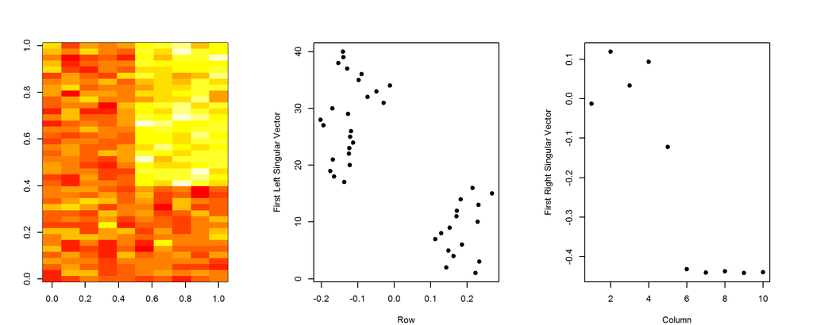

```r
svd1 <- svd(scale(dmOrdered))

par(mfrow=c(1,3), mar=c(4,4,4,4))

image(t(dmOrdered)[ ,nrow(dmOrdered):1])
plot(svd1$u[ ,1], 40:1, xlab="Row", ylab="First Left Singular Vector", pch=19)
plot(svd1$v[ ,1], xlab="Column", ylab="First Right Singular Vector", pch=19)
```

### Components of SVD: Variance explained: D

- D is the diagonal Matrix component.
- The values of D represent the “magnitute of effect” or strength for each variable (column).
- the svd function orders the diagonal by strength.
- In the plots below, the left plot shows the raw D values, while the right is normalized. So the right plot shows that the first column is responsible for 40% of effect. Column2 approximately 15%, etc.

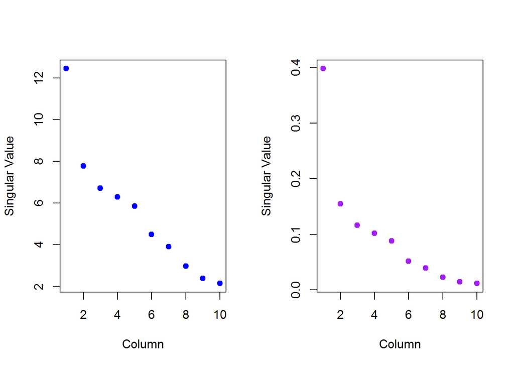

```r
#SVD Component D
par(mfrow=c(1,2))
plot(svd1$d, xlab = "Column", ylab="Singular Value", pch=19, col="blue")
plot(svd1$d^2/sum(svd1$d^2), xlab="Column", ylab="Singular Value", pch = 19, col="purple")
```

### A quick tangent to show off smoothScatter()…

- good way to plot a very large dataset.

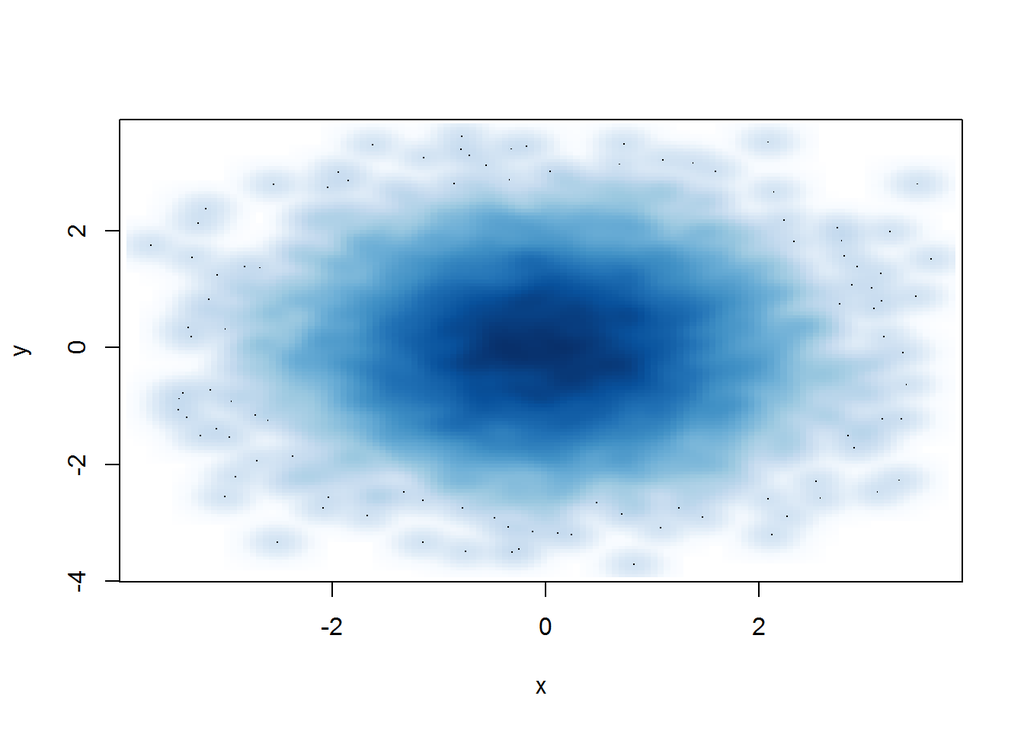

```r
y <- rnorm(10000)
x <- rnorm(10000)
smoothScatter(x,y)
```